# Penguin Classification

##### Mean Linkage

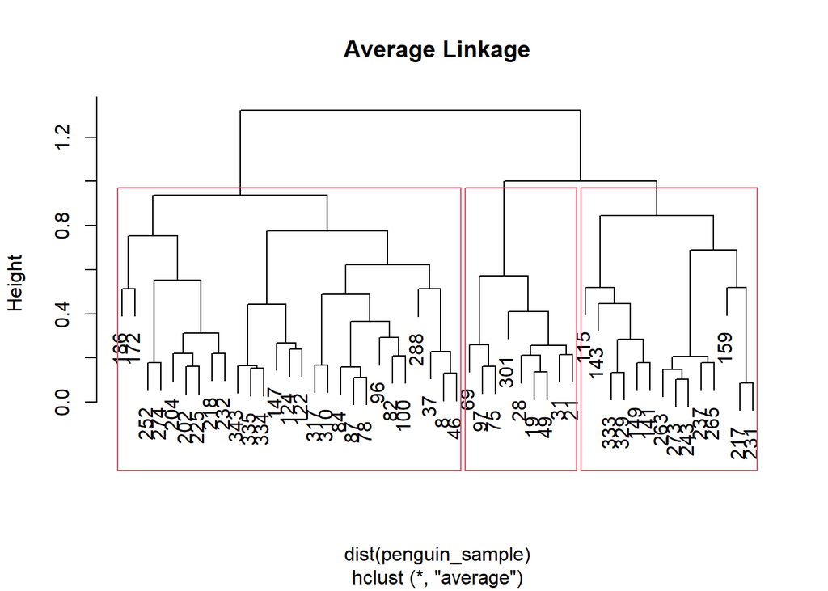

```r
set.seed(123)

# Mean Linkage (no disponible directamente en hclust, podemos usar 'average' como alternativa)
hc_average <- hclust(dist(penguin_sample), method = "average")
plot(hc_average, main = "Average Linkage")
rect.hclust(hc_average,k=3)
```

```r
groups <- cutree(hc_average,k=3)
print(groups)
```

```
## 186  19 202 317 124 310 237 252 343 159  96  97 265 204 333 143  31   8 329 263
##   1   2   1   1   1   1   3   1   1   3   1   2   3   1   3   3   2   1   3   3
## 218  84  87  49 149  37 115 274  28 141 232 172 225 301  75  78  82  69 147 217
##   1   1   1   2   3   1   3   1   2   3   1   1   1   2   2   1   1   2   1   3
## 335 288  46 334 231  21 122 100 273 243
##   1   1   1   1   3   2   1   1   3   3
```

#### 3.3.2 Aglomertive clustering model (agnes)

Let’s keep developing aglomerative clustering models, but using agnes library now:

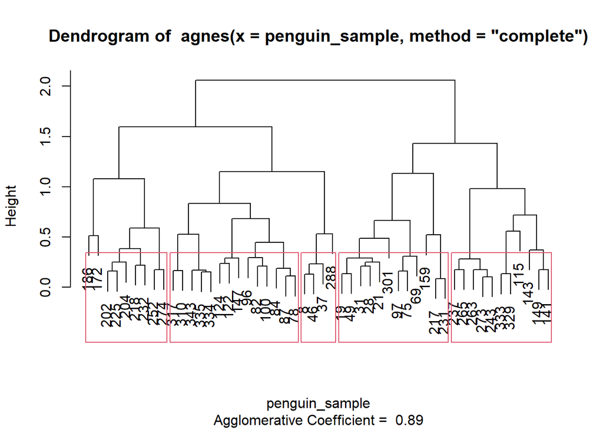

```r
# Usando agnes para complete linkage como ejemplo
agnes_complete <- agnes(penguin_sample, method = "complete")
plot(agnes_complete, which.plots = 2)

rect.hclust(agnes_complete,k=5)
```

```r
groups <- cutree(agnes_complete,k=5)
print(groups)
```

```
## 186  19 202 317 124 310 237 252 343 159  96  97 265 204 333 143  31   8 329 263
##   1   2   1   3   3   3   4   1   3   2   3   2   4   1   4   4   2   5   4   4
## 218  84  87  49 149  37 115 274  28 141 232 172 225 301  75  78  82  69 147 217
##   1   3   3   2   4   5   4   1   2   4   1   1   1   2   2   3   3   2   3   2
## 335 288  46 334 231  21 122 100 273 243
##   3   5   5   3   2   2   3   3   4   4
```

#### 3.3.3 Divisive hierarchical clustering (diana)

Let’s finally try diana library and it’s divisive clustering:

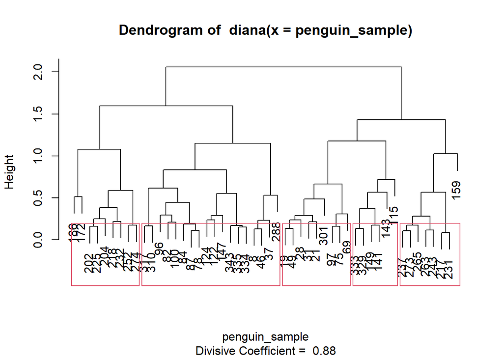

```r
# Clustering divisivo
diana_model <- diana(penguin_sample)
plot(diana_model, which.plots = 2)
rect.hclust(diana_model,k=5)
```

```r
groups <- cutree(diana_model,k=5)
print(groups)
```

```
## 186  19 202 317 124 310 237 252 343 159  96  97 265 204 333 143  31   8 329 263
##   1   2   1   3   3   3   4   1   3   4   3   2   4   1   5   5   2   3   5   4
## 218  84  87  49 149  37 115 274  28 141 232 172 225 301  75  78  82  69 147 217
##   1   3   3   2   5   3   5   1   2   5   1   1   1   2   2   3   3   2   3   4
## 335 288  46 334 231  21 122 100 273 243
##   3   3   3   3   4   2   3   3   4   4
```

### 4. Conclusions

Our final conclusion is that penguins can be grouped in so many different ways, as it is a subjective grouping method. We could grup them according to sex or other categorical columns, only pulling apart males from females, but you can make different groups such as:

·Sex && Body Mass ·Sex && Bill length/depth ·Sex && Flipper length

These are combinations that make more sense for us. We could probably find other grouping criterias but, as we said earlier, it is a subjective task.For example, imagine that you have a male penguin with a determined Bill length, he would probably enter the group of medium long bills males. Given two variables, we could classify them as into new clusters. Previous combinations make more sense because numerical values could be splitted in small, medium or large.We could also have fitted all penguin features into K-means but that would have involved a lot of variables. It could also be a choice to use all variables that you want. We can only see it’s divisions with 3 variables(3D graphics).

We have achieved our goals by trying different models, specially different k values in K-Means/K-Medoids.We think partitioning clustering works better with this problem as it is more visual and clear, referring to K-means and K-medoids